# EXPLORATORY DATA ANALYSIS COURSE PROJECT

### Inference:

-Improvement in Vaccination can eradicate infant death due to Measles.

### %death due to Measles Divsion-wise

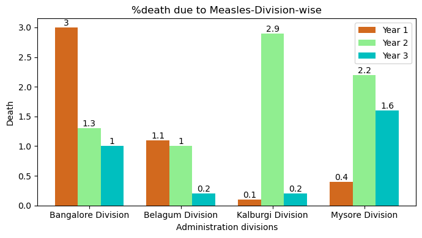

```python
import matplotlib.pyplot as plt

labels = ["Bangalore Division", "Belagum Division", "Kalburgi Division", "Mysore Division"]
year_1 = [3,1.1,0.1,0.4]
year_2 = [1.3,1,2.9,2.2]  # Replace these values with data for the second year
year_3 = [1,0.2,0.2,1.6] #Replace these values with data for the third year

bar_width = 0.25  # Width of each bar
bar_positions_1 = list(range(len(labels)))
bar_positions_2 = [pos + bar_width for pos in bar_positions_1]
bar_positions_3 = [pos + bar_width * 2 for pos in bar_positions_1]

# Horizontal bar chart with custom colors
plt.figure(figsize=(7, 4))
bars1 = plt.bar(bar_positions_1, year_1, width=bar_width, color="chocolate", label='Year 1')
bars2 = plt.bar(bar_positions_2, year_2, width=bar_width, color="lightgreen", label='Year 2')
bars3 = plt.bar(bar_positions_3, year_3, width=bar_width, color="c", label='Year 3')

# Title and labels
plt.title('%death due to Measles-Division-wise')
plt.xlabel('Administration divisions')
plt.ylabel('Death')

# Display the values on top of each bar for year 1
for i, bar in enumerate(bars1):
    plt.text(bar.get_x() + bar.get_width() / 2, bar.get_height(),
             year_1[i], ha='center', va='bottom')

# Display the values on top of each bar for year 2
for i, bar in enumerate(bars2):
    plt.text(bar.get_x() + bar.get_width() / 2, bar.get_height(),
             year_2[i], ha='center', va='bottom')

# Display the values on top of each bar for year 3
for i, bar in enumerate(bars3):
    plt.text(bar.get_x() + bar.get_width() / 2, bar.get_height(),
             year_3[i], ha='center', va='bottom')

# Set the x-axis ticks and labels
plt.xticks([pos + bar_width for pos in bar_positions_1], labels)

# Add a legend
plt.legend()

# Display the chart
plt.tight_layout()
plt.show()
```

## Q26.What is the % of Death caused due to Measles District-wise?

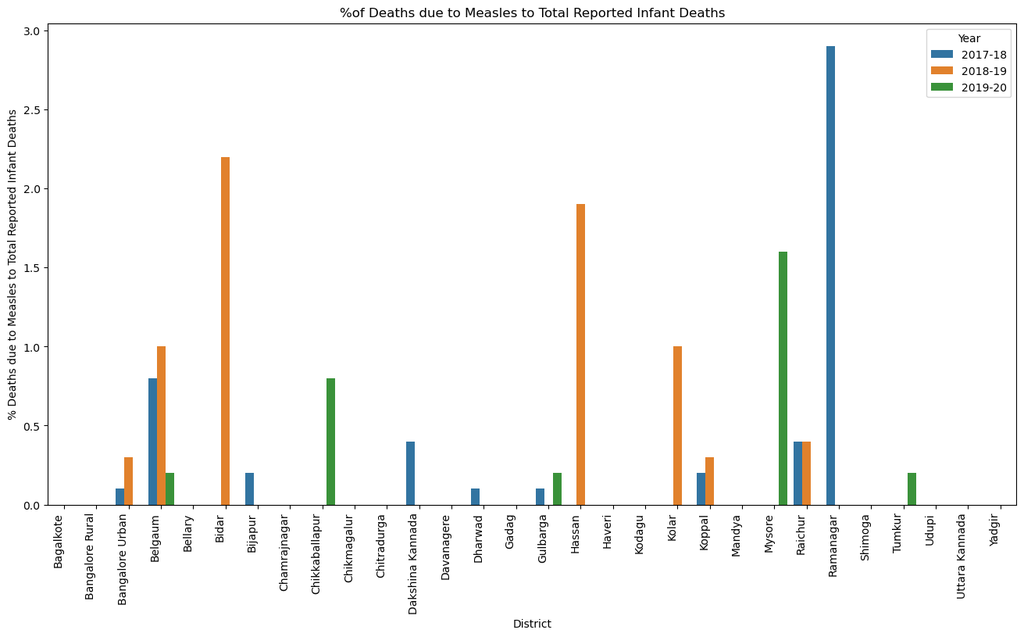

```python
fig, ax=plt.subplots(figsize=(16,8))
sns.barplot(data=names, x="District", y="% Deaths due to Measles to Total Reported Infant Deaths", hue = 'Year',ax=ax)
ax.set_xticklabels(ax.get_xticklabels(),rotation=90,horizontalalignment='right')
plt.title("%of Deaths due to Measles to Total Reported Infant Deaths")
plt.show()
```

### Inference:

-In 2017-18, Ramnagar has recorded highest %of infant death due to Measles.

-In 2018-19, Bidar has recorded highest %of infant death due to Measles.

-In 2019-20, Mysore has recorded highest %of infant death due to Measles.

## Q27.What is the total number of Infants affected due to Diarrhoea?

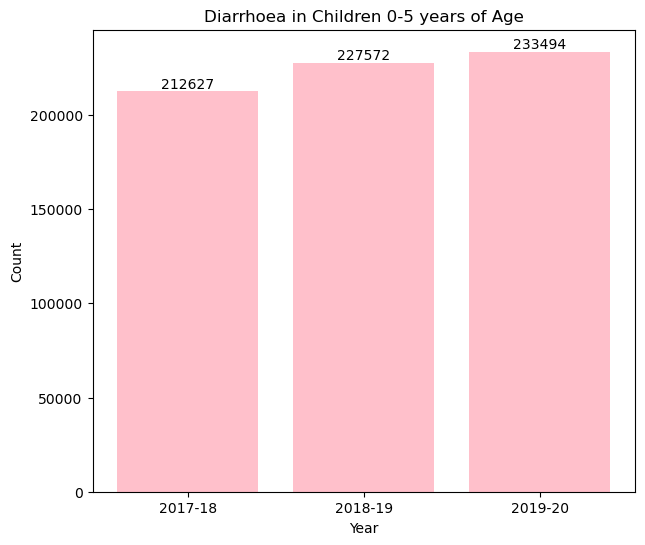

```python
import matplotlib.pyplot as plt

labels = ["2017-18", "2018-19", "2019-20"]
sizes = [212627,227572,233494]

# Horizontal bar chart with custom colors
plt.figure(figsize=(7, 6))
bars = plt.bar(labels, sizes,color='pink')

# Title and labels
plt.title('Diarrhoea in Children 0-5 years of Age')
plt.xlabel('Year')
plt.ylabel('Count')

# Display the values on top of each bar
for i, bar in enumerate(bars):
    plt.text(bar.get_x() + bar.get_width() / 2, bar.get_height(),
             sizes[i], ha='center', va='bottom')

# Display the chart
plt.show()
```

### Inference:

-This graph gives the number of infants infected due to Diarrhoea in Karnataka which is increasing over 3 years.

Reasons:

-Diarrhoea is a water borne disease caused due to contaminated water. Infection in intestine caused due to virus(such as rotavirus).

## Q28.What is the number of Death caused due to Diarrhoea?

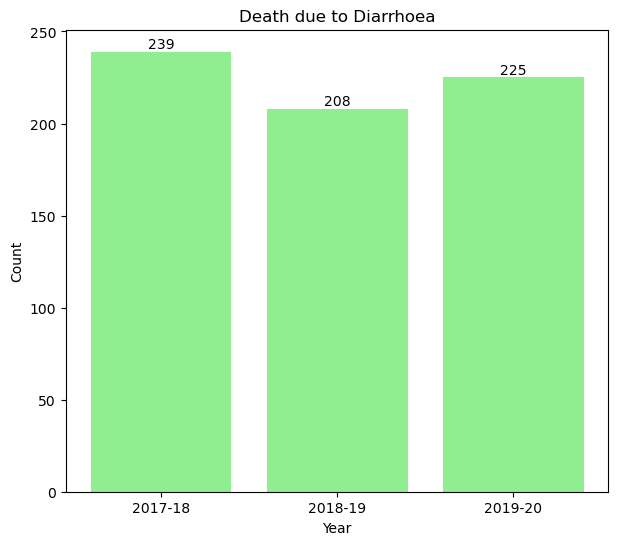

```python
import matplotlib.pyplot as plt

labels = ["2017-18", "2018-19", "2019-20"]
sizes = [239,208,225]

# Horizontal bar chart with custom colors
plt.figure(figsize=(7, 6))
bars = plt.bar(labels, sizes,color='lightgreen')

# Title and labels
plt.title('Death due to Diarrhoea')
plt.xlabel('Year')
plt.ylabel('Count')

# Display the values on top of each bar
for i, bar in enumerate(bars):
    plt.text(bar.get_x() + bar.get_width() / 2, bar.get_height(),
             sizes[i], ha='center', va='bottom')

# Display the chart
plt.show()
```

### Inference:

-This graph gives the number of infant death caused due to Diarrhoea across all districts of Karnataka.

Reasons:

-Untreated Diarrhoea leads to loss of water and essential nutrients in the body which can lead to death.

## Q29.What is the number of infants recovered from Diarrhoea?

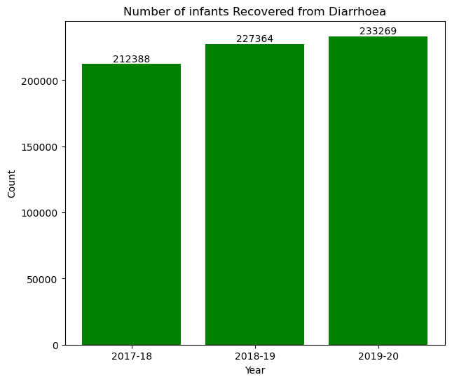

```python
import matplotlib.pyplot as plt

labels = ["2017-18", "2018-19", "2019-20"]
sizes = [212388,227364,233269]

# Horizontal bar chart with custom colors
plt.figure(figsize=(7, 6))
bars = plt.bar(labels, sizes,color='g')

# Title and labels
plt.title('Number of infants Recovered from Diarrhoea')
plt.xlabel('Year')
plt.ylabel('Count')

# Display the values on top of each bar
for i, bar in enumerate(bars):
    plt.text(bar.get_x() + bar.get_width() / 2, bar.get_height(),
             sizes[i], ha='center', va='bottom')

# Display the chart
plt.show()
```

### Inference:

-The graph infers about the number of infants recovered from Diarrhoea.

-The number of infants recovering from affected has been increasing.

## Infants received Rotavirus Vaccine 1st Dose

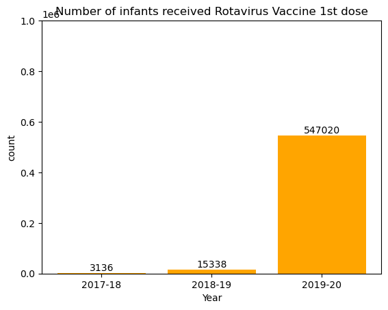

```python
#Total Number of reporated delivaries
sums = names.groupby('Year')['No. of infants received Rotavirus Vaccine 1st dose'].sum()
years = list(sums.keys())
# Plotting the bar graph
bars = plt.bar(years, sums,color="orange")

# Adding labels and title
plt.xlabel('Year')
plt.ylabel('count')
plt.title('Number of infants received Rotavirus Vaccine 1st dose')

# Set the y-axis limits
plt.ylim([0, 1000000])

# Display the values on top of each bar
for bar in bars:
    height = bar.get_height()
    plt.text(bar.get_x() + bar.get_width() / 2, height, str(height),
             ha='center', va='bottom')

# Display the graph
plt.show()
```

## Infants received Rotavirus Vaccine 2nd Dose

[figure not shown]

```python
#Total Number of reporated delivaries
sums = names.groupby('Year')['No. of infants received Rotavirus Vaccine 2nd dose'].sum()
years = list(sums.keys())
# Plotting the bar graph
bars = plt.bar(years, sums,color="green")

# Adding labels and title
plt.xlabel('Year')
plt.ylabel('count')
plt.title('Number of infants received Rotavirus Vaccine 1st dose')

# Set the y-axis limits
plt.ylim([0, 1000000])

# Display the values on top of each bar
for bar in bars:
    height = bar.get_height()
    plt.text(bar.get_x() + bar.get_width() / 2, height, str(height),
             ha='center', va='bottom')

# Display the graph
plt.show()
```

## Infants received Rotavirus Vaccine 3rd Dose

[figure not shown]

```python
#Total Number of reporated delivaries
sums = names.groupby('Year')['No. of infants received Rotavirus Vaccine 3rd dose'].sum()
years = list(sums.keys())
# Plotting the bar graph
bars = plt.bar(years, sums,color="red")

# Adding labels and title
plt.xlabel('Year')
plt.ylabel('count')
plt.title('Number of infants received Rotavirus Vaccine 1st dose')

# Set the y-axis limits
plt.ylim([0, 1000000])

# Display the values on top of each bar
for bar in bars:
    height = bar.get_height()
    plt.text(bar.get_x() + bar.get_width() / 2, height, str(height),
             ha='center', va='bottom')

# Display the graph
plt.show()
```

### Inference:

-Number of infants that have received Rotavirus Vaccination has increased from year to year.

-But substantially the intake of 2nd & 3rd dose has been decreased compared to 1st dose.

-Rotavirus vaccination is given to the infant to prevent them from getting infected with Diarrhoea (caused by rotavirus).

### %death due to Diarrhoea Division-wise

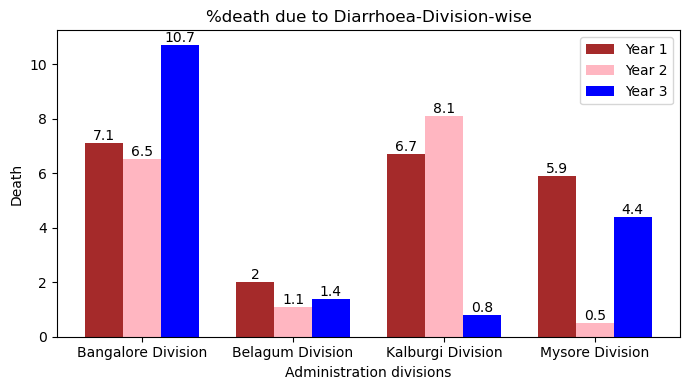

```python
import matplotlib.pyplot as plt

labels = ["Bangalore Division", "Belagum Division", "Kalburgi Division", "Mysore Division"]
year_1 = [7.1,2,6.7,5.9]
year_2 = [6.5,1.1,8.1,0.5]  # Replace these values with data for the second year
year_3 = [10.7,1.4,0.8,4.4] #Replace these values with data for the third year

bar_width = 0.25  # Width of each bar
bar_positions_1 = list(range(len(labels)))
bar_positions_2 = [pos + bar_width for pos in bar_positions_1]
bar_positions_3 = [pos + bar_width * 2 for pos in bar_positions_1]

# Horizontal bar chart with custom colors
plt.figure(figsize=(7, 4))
bars1 = plt.bar(bar_positions_1, year_1, width=bar_width, color="brown", label='Year 1')
bars2 = plt.bar(bar_positions_2, year_2, width=bar_width, color="lightpink", label='Year 2')
bars3 = plt.bar(bar_positions_3, year_3, width=bar_width, color="blue", label='Year 3')

# Title and labels
plt.title('%death due to Diarrhoea-Division-wise')
plt.xlabel('Administration divisions')
plt.ylabel('Death')

# Display the values on top of each bar for year 1
for i, bar in enumerate(bars1):
    plt.text(bar.get_x() + bar.get_width() / 2, bar.get_height(),
             year_1[i], ha='center', va='bottom')

# Display the values on top of each bar for year 2
for i, bar in enumerate(bars2):
    plt.text(bar.get_x() + bar.get_width() / 2, bar.get_height(),
             year_2[i], ha='center', va='bottom')

# Display the values on top of each bar for year 3
for i, bar in enumerate(bars3):
    plt.text(bar.get_x() + bar.get_width() / 2, bar.get_height(),
             year_3[i], ha='center', va='bottom')

# Set the x-axis ticks and labels
plt.xticks([pos + bar_width for pos in bar_positions_1], labels)

# Add a legend
plt.legend()

# Display the chart
plt.tight_layout()
plt.show()
```

## Q30.What is the % of Death caused due to Diarrhoea District-wise?

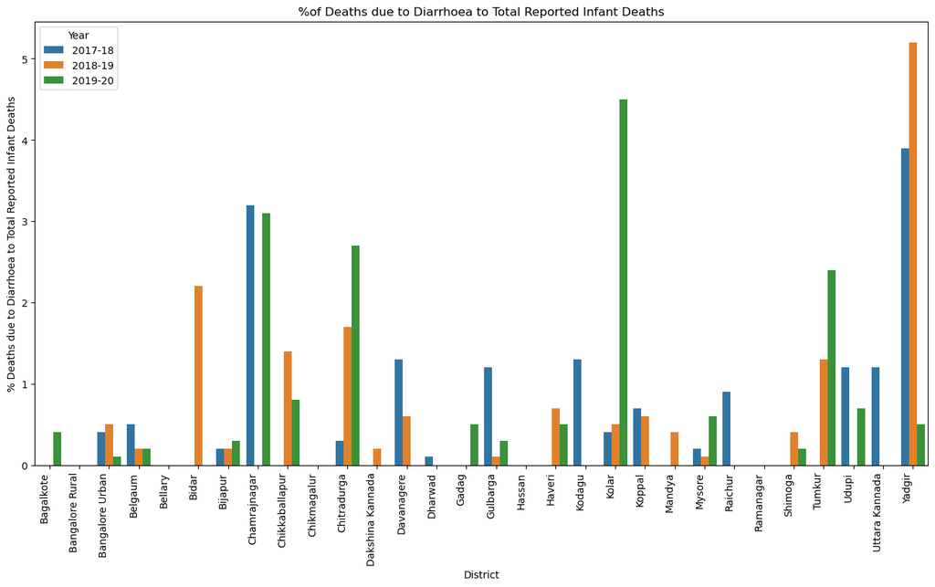

```python
fig, ax=plt.subplots(figsize=(16,8))
sns.barplot(data=names, x="District", y="% Deaths due to Diarrhoea to Total Reported Infant Deaths", hue = 'Year',ax=ax)
ax.set_xticklabels(ax.get_xticklabels(),rotation=90,horizontalalignment='right')
plt.title("%of Deaths due to Diarrhoea to Total Reported Infant Deaths")
plt.show()
```

### Inference:

-In 2017-18, Yadgir has recorded highest %of infant death due to Diarrhoea.

-In 2018-19, Yadgir has recorded highest %of infant death due to Diarrhoea.

-In 2019-20, Kolar has recorded highest %of infant death due to Diarrhoea.

## Some of the Common Health Issues Faced by the Infants

### Diphtheria in Children 0-5 Years of Age

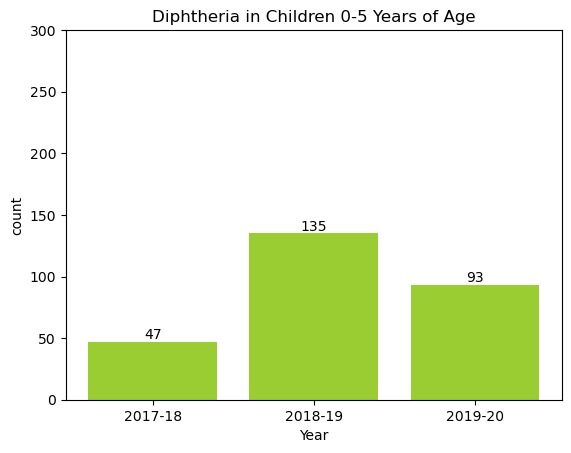

```python
sums = names.groupby('Year')['Diphtheria in Children 0-5 Years of Age'].sum()
years = list(sums.keys())
# Plotting the bar graph
bars = plt.bar(years, sums,color="yellowgreen")

# Adding labels and title
plt.xlabel('Year')
plt.ylabel('count')
plt.title('Diphtheria in Children 0-5 Years of Age')

# Set the y-axis limits
plt.ylim([0,300])

# Display the values on top of each bar
for bar in bars:
    height = bar.get_height()
    plt.text(bar.get_x() + bar.get_width() / 2, height, str(height),
             ha='center', va='bottom')

# Display the graph
plt.show()
```

### Pertussis in Children 0-5 Years of Age

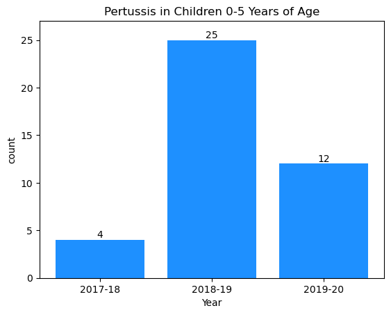

```python
sums = names.groupby('Year')['Pertussis in Children 0-5 Years of Age'].sum()
years = list(sums.keys())
# Plotting the bar graph
bars = plt.bar(years, sums,color="dodgerblue")

# Adding labels and title
plt.xlabel('Year')
plt.ylabel('count')
plt.title('Pertussis in Children 0-5 Years of Age')

# Set the y-axis limits
plt.ylim([0,27])

# Display the values on top of each bar
for bar in bars:
    height = bar.get_height()
    plt.text(bar.get_x() + bar.get_width() / 2, height, str(height),
             ha='center', va='bottom')

# Display the graph
plt.show()
```

### Tetanus Neonatorum in Children 0-5 Years of Age

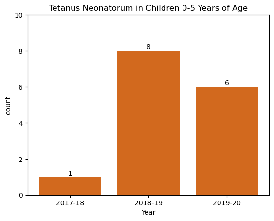

```python
sums = names.groupby('Year')['Tetanus Neonatorum in Children 0-5 Years of Age'].sum()
years = list(sums.keys())
# Plotting the bar graph
bars = plt.bar(years, sums,color="chocolate")

# Adding labels and title
plt.xlabel('Year')
plt.ylabel('count')
plt.title('Tetanus Neonatorum in Children 0-5 Years of Age')

# Set the y-axis limits
plt.ylim([0,10])

# Display the values on top of each bar
for bar in bars:
    height = bar.get_height()
    plt.text(bar.get_x() + bar.get_width() / 2, height, str(height),
             ha='center', va='bottom')

# Display the graph
plt.show()
```

#### These are some health issues faced by the infants

#### But the number of infected infants due to the above diseases is less as compared to Asphyxia, Sepsis, Measles, Diarrhoea.

## Diphtheria, Pertussis, Tetanus Neonatorum in Karnataka(district-wise)

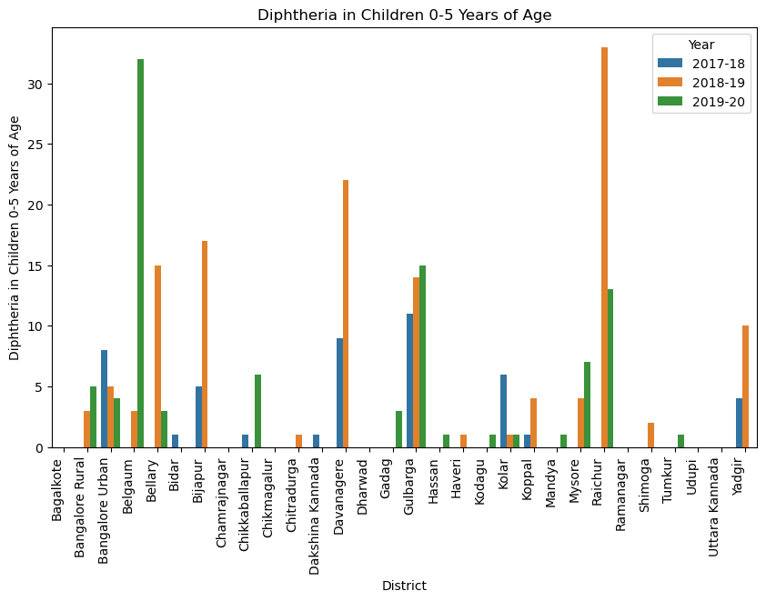

```python
fig, ax=plt.subplots(figsize=(10,6))
sns.barplot(data=names, x="District", y="Diphtheria in Children 0-5 Years of Age", hue = 'Year',ax=ax)
ax.set_xticklabels(ax.get_xticklabels(),rotation=90,horizontalalignment='right')
plt.title("Diphtheria in Children 0-5 Years of Age")
plt.show()
```

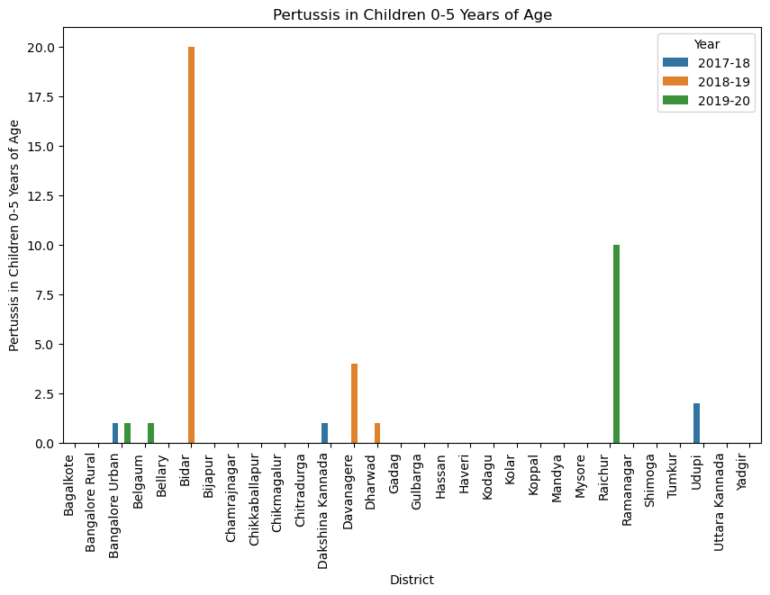

```python
fig, ax=plt.subplots(figsize=(10,6))
sns.barplot(data=names, x="District", y="Pertussis in Children 0-5 Years of Age", hue = 'Year',ax=ax)
ax.set_xticklabels(ax.get_xticklabels(),rotation=90,horizontalalignment='right')
plt.title("Pertussis in Children 0-5 Years of Age")
plt.show()
```

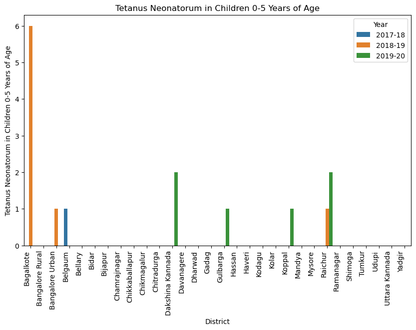

```python
fig, ax=plt.subplots(figsize=(10,6))
sns.barplot(data=names, x="District", y="Tetanus Neonatorum in Children 0-5 Years of Age", hue = 'Year',ax=ax)
ax.set_xticklabels(ax.get_xticklabels(),rotation=90,horizontalalignment='right')
plt.title("Tetanus Neonatorum in Children 0-5 Years of Age")
plt.show()
```

## DPT1 DPT2 DPT3 Vaccination given to Infants

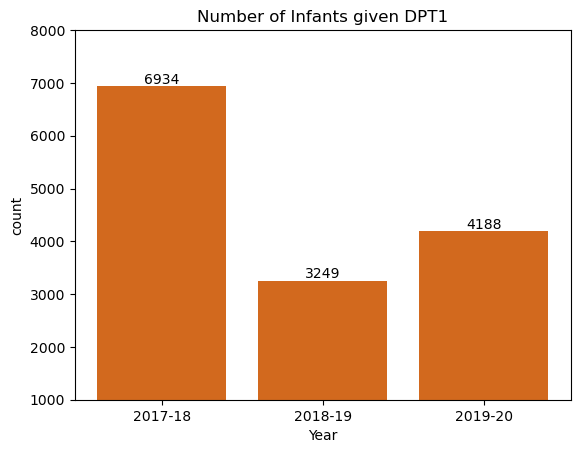

```python
sums = names.groupby('Year')['Number of Infants given DPT1'].sum()
years = list(sums.keys())
# Plotting the bar graph
bars = plt.bar(years, sums,color="chocolate")

# Adding labels and title
plt.xlabel('Year')
plt.ylabel('count')
plt.title('Number of Infants given DPT1')

# Set the y-axis limits
plt.ylim([1000,8000])

# Display the values on top of each bar
for bar in bars:
    height = bar.get_height()
    plt.text(bar.get_x() + bar.get_width() / 2, height, str(height),
             ha='center', va='bottom')

# Display the graph
plt.show()
```

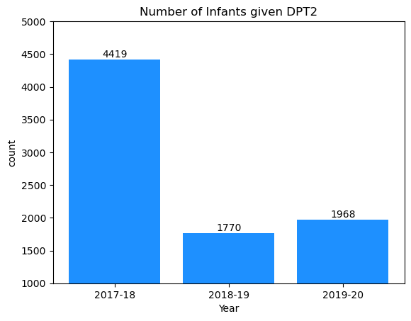

```python
sums = names.groupby('Year')['Number of Infants given DPT2'].sum()
years = list(sums.keys())
# Plotting the bar graph
bars = plt.bar(years, sums,color="dodgerblue")

# Adding labels and title
plt.xlabel('Year')
plt.ylabel('count')
plt.title('Number of Infants given DPT2')

# Set the y-axis limits
plt.ylim([1000,5000])

# Display the values on top of each bar
for bar in bars:
    height = bar.get_height()
    plt.text(bar.get_x() + bar.get_width() / 2, height, str(height),
             ha='center', va='bottom')

# Display the graph
plt.show()
```

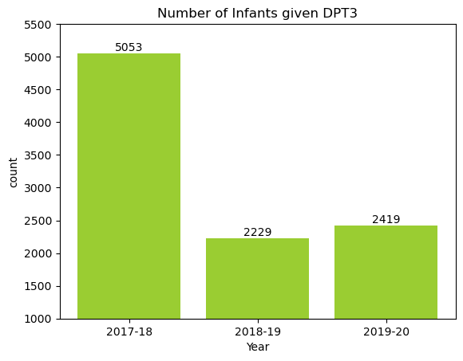

```python
sums = names.groupby('Year')['Number of Infants given DPT3'].sum()
years = list(sums.keys())
# Plotting the bar graph
bars = plt.bar(years, sums,color="yellowgreen")

# Adding labels and title
plt.xlabel('Year')
plt.ylabel('count')
plt.title('Number of Infants given DPT3')

# Set the y-axis limits
plt.ylim([1000,5500])

# Display the values on top of each bar
for bar in bars:
    height = bar.get_height()
    plt.text(bar.get_x() + bar.get_width() / 2, height, str(height),
             ha='center', va='bottom')

# Display the graph
plt.show()
```

## DPT Vaccine Distribution Division-wise

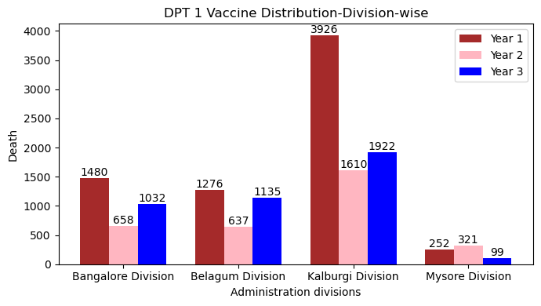

```python
import matplotlib.pyplot as plt

labels = ["Bangalore Division", "Belagum Division", "Kalburgi Division", "Mysore Division"]
year_1 = [1480,1276,3926,252]
year_2 = [658,637,1610,321]  # Replace these values with data for the second year
year_3 = [1032,1135,1922,99] #Replace these values with data for the third year

bar_width = 0.25  # Width of each bar
bar_positions_1 = list(range(len(labels)))
bar_positions_2 = [pos + bar_width for pos in bar_positions_1]
bar_positions_3 = [pos + bar_width * 2 for pos in bar_positions_1]

# Horizontal bar chart with custom colors
plt.figure(figsize=(7, 4))
bars1 = plt.bar(bar_positions_1, year_1, width=bar_width, color="brown", label='Year 1')
bars2 = plt.bar(bar_positions_2, year_2, width=bar_width, color="lightpink", label='Year 2')
bars3 = plt.bar(bar_positions_3, year_3, width=bar_width, color="blue", label='Year 3')

# Title and labels
plt.title('DPT 1 Vaccine Distribution-Division-wise')
plt.xlabel('Administration divisions')
plt.ylabel('Death')

# Display the values on top of each bar for year 1
for i, bar in enumerate(bars1):
    plt.text(bar.get_x() + bar.get_width() / 2, bar.get_height(),
             year_1[i], ha='center', va='bottom')

# Display the values on top of each bar for year 2
for i, bar in enumerate(bars2):
    plt.text(bar.get_x() + bar.get_width() / 2, bar.get_height(),
             year_2[i], ha='center', va='bottom')

# Display the values on top of each bar for year 3
for i, bar in enumerate(bars3):
    plt.text(bar.get_x() + bar.get_width() / 2, bar.get_height(),
             year_3[i], ha='center', va='bottom')

# Set the x-axis ticks and labels
plt.xticks([pos + bar_width for pos in bar_positions_1], labels)

# Add a legend
plt.legend()

# Display the chart
plt.tight_layout()
plt.show()
```

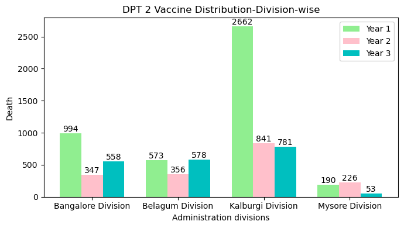

```python
import matplotlib.pyplot as plt

labels = ["Bangalore Division", "Belagum Division", "Kalburgi Division", "Mysore Division"]
year_1 = [994,573,2662,190]
year_2 = [347,356,841,226]  # Replace these values with data for the second year
year_3 = [558,578,781,53] #Replace these values with data for the third year

bar_width = 0.25  # Width of each bar
bar_positions_1 = list(range(len(labels)))
bar_positions_2 = [pos + bar_width for pos in bar_positions_1]
bar_positions_3 = [pos + bar_width * 2 for pos in bar_positions_1]

# Horizontal bar chart with custom colors
plt.figure(figsize=(7, 4))
bars1 = plt.bar(bar_positions_1, year_1, width=bar_width, color="lightgreen", label='Year 1')
bars2 = plt.bar(bar_positions_2, year_2, width=bar_width, color="pink", label='Year 2')
bars3 = plt.bar(bar_positions_3, year_3, width=bar_width, color="c", label='Year 3')

# Title and labels
plt.title('DPT 2 Vaccine Distribution-Division-wise')
plt.xlabel('Administration divisions')
plt.ylabel('Death')

# Display the values on top of each bar for year 1
for i, bar in enumerate(bars1):
    plt.text(bar.get_x() + bar.get_width() / 2, bar.get_height(),
             year_1[i], ha='center', va='bottom')

# Display the values on top of each bar for year 2
for i, bar in enumerate(bars2):
    plt.text(bar.get_x() + bar.get_width() / 2, bar.get_height(),
             year_2[i], ha='center', va='bottom')

# Display the values on top of each bar for year 3
for i, bar in enumerate(bars3):
    plt.text(bar.get_x() + bar.get_width() / 2, bar.get_height(),
             year_3[i], ha='center', va='bottom')

# Set the x-axis ticks and labels
plt.xticks([pos + bar_width for pos in bar_positions_1], labels)

# Add a legend
plt.legend()

# Display the chart
plt.tight_layout()
plt.show()
```

[figure not shown]

```python
import matplotlib.pyplot as plt

labels = ["Bangalore Division", "Belagum Division", "Kalburgi Division", "Mysore Division"]
year_1 = [1043,868,3057,122]
year_2 = [412,646,1034,140]  # Replace these values with data for the second year
year_3 = [657,701,970,114] #Replace these values with data for the third year

bar_width = 0.25  # Width of each bar
bar_positions_1 = list(range(len(labels)))
bar_positions_2 = [pos + bar_width for pos in bar_positions_1]
bar_positions_3 = [pos + bar_width * 2 for pos in bar_positions_1]

# Horizontal bar chart with custom colors
plt.figure(figsize=(7, 4))
bars1 = plt.bar(bar_positions_1, year_1, width=bar_width, color="r", label='Year 1')
bars2 = plt.bar(bar_positions_2, year_2, width=bar_width, color="pink", label='Year 2')
bars3 = plt.bar(bar_positions_3, year_3, width=bar_width, color="b", label='Year 3')

# Title and labels
plt.title('DPT 2 Vaccine Distribution-Division-wise')
plt.xlabel('Administration divisions')
plt.ylabel('Death')

# Display the values on top of each bar for year 1
for i, bar in enumerate(bars1):
    plt.text(bar.get_x() + bar.get_width() / 2, bar.get_height(),
             year_1[i], ha='center', va='bottom')

# Display the values on top of each bar for year 2
for i, bar in enumerate(bars2):
    plt.text(bar.get_x() + bar.get_width() / 2, bar.get_height(),
             year_2[i], ha='center', va='bottom')

# Display the values on top of each bar for year 3
for i, bar in enumerate(bars3):
    plt.text(bar.get_x() + bar.get_width() / 2, bar.get_height(),
             year_3[i], ha='center', va='bottom')

# Set the x-axis ticks and labels
plt.xticks([pos + bar_width for pos in bar_positions_1], labels)

# Add a legend
plt.legend()

# Display the chart
plt.tight_layout()
plt.show()
```

## DPT Vaccine Distribution in Karnataka(District-wise)

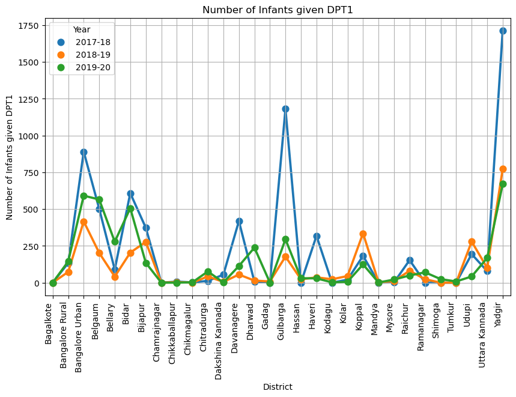

```python
fig, ax=plt.subplots(figsize=(10,6))
sns.pointplot(data=names, x="District", y="Number of Infants given DPT1", hue = 'Year',ax=ax)
ax.set_xticklabels(ax.get_xticklabels(),rotation=90,horizontalalignment='right')
ax.grid(True)
plt.title("Number of Infants given DPT1")
plt.show()
```

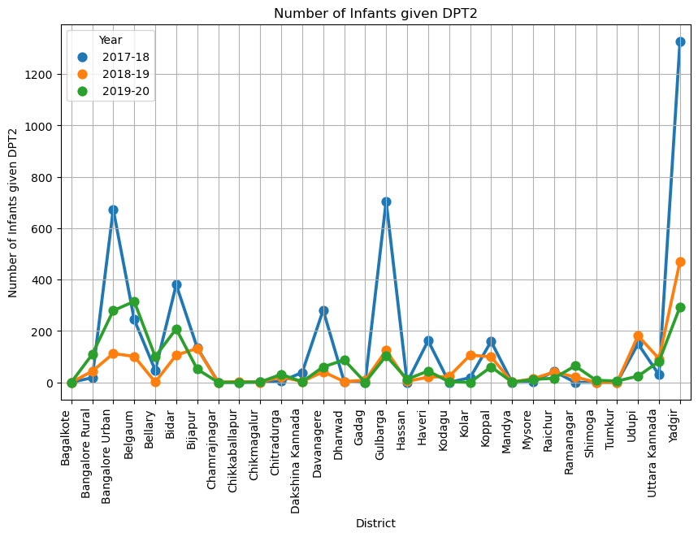

```python
fig, ax=plt.subplots(figsize=(10,6))
sns.pointplot(data=names, x="District", y="Number of Infants given DPT2", hue = 'Year',ax=ax)
ax.set_xticklabels(ax.get_xticklabels(),rotation=90,horizontalalignment='right')
ax.grid(True)
plt.title("Number of Infants given DPT2")
plt.show()
```

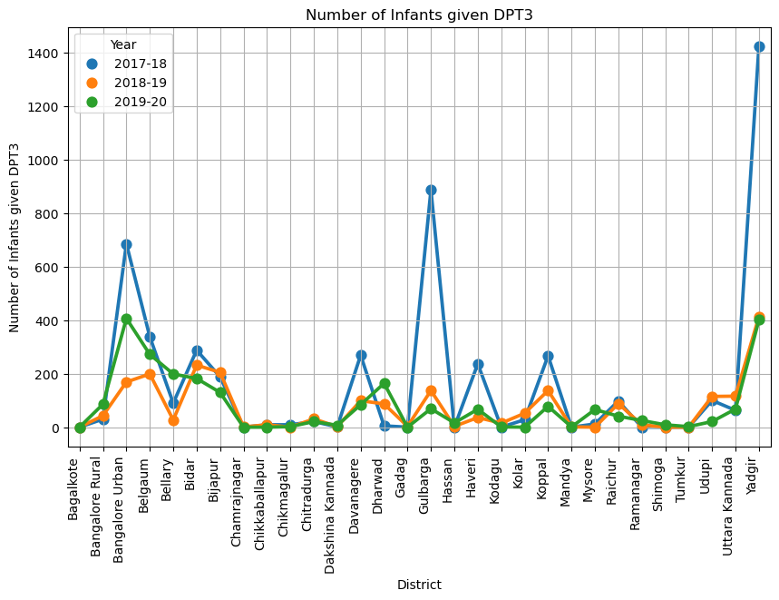

```python
fig, ax=plt.subplots(figsize=(10,6))
sns.pointplot(data=names, x="District", y="Number of Infants given DPT3", hue = 'Year',ax=ax)
ax.set_xticklabels(ax.get_xticklabels(),rotation=90,horizontalalignment='right')
ax.grid(True)
plt.title("Number of Infants given DPT3")
plt.show()
```

## TuberCulosis in Children 0-5 Years of Age in Karnataka

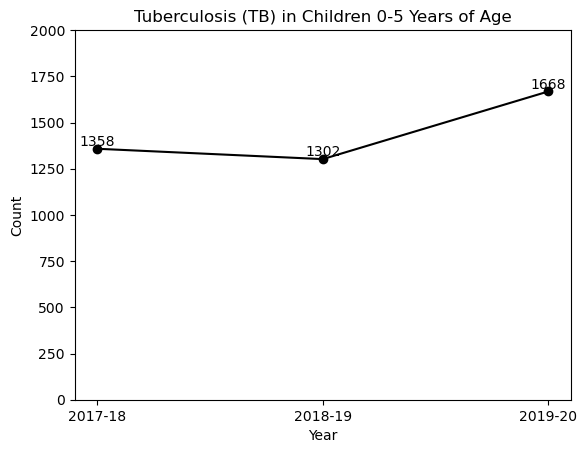

```python
import matplotlib.pyplot as plt

# Assuming you have already defined the 'names' DataFrame and computed 'sums'
sums = names.groupby('Year')['Tuberculosis (TB) in Children 0-5 Years of Age'].sum()
years = list(sums.keys())

# Plotting the line graph
plt.plot(years, sums, marker='o', color='black', linestyle='-')

# Adding labels and title
plt.xlabel('Year')
plt.ylabel('Count')
plt.title('Tuberculosis (TB) in Children 0-5 Years of Age')

# Set the y-axis limits
plt.ylim([0, 2000])

# Display the values on top of each data point
for i in range(len(years)):
    plt.text(years[i], sums[i], str(sums[i]), ha='center', va='bottom')

# Display the graph
plt.show()
```

[figure not shown]

```python
fig, ax=plt.subplots(figsize=(10,6))
sns.barplot(data=names, x="District", y="Tuberculosis (TB) in Children 0-5 Years of Age", hue = 'Year',ax=ax)
ax.set_xticklabels(ax.get_xticklabels(),rotation=90,horizontalalignment='right')
ax.grid(True)
plt.title("Number of Infants given BCG")
plt.show()
```

## BCG Vaccine given across Districts of Karnataka

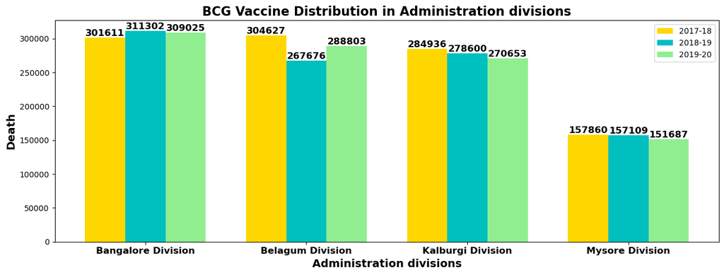

```python
import matplotlib.pyplot as plt

labels = ["Bangalore Division", "Belagum Division", "Kalburgi Division", "Mysore Division"]
year_1 = [301611,304627,284936,157860]
year_2 = [311302,267676,278600,157109]  # Replace these values with data for the second year
year_3 = [309025,288803,270653,151687] #Replace these values with data for the third year


bar_width = 0.25  # Width of each bar
bar_positions_1 = list(range(len(labels)))
bar_positions_2 = [pos + bar_width for pos in bar_positions_1]
bar_positions_3 = [pos + bar_width * 2 for pos in bar_positions_1]

# Horizontal bar chart with custom colors
plt.figure(figsize=(13, 5))  # Increase the figure size to make the text more visible
bars1 = plt.bar(bar_positions_1, year_1, width=bar_width, color="gold", label='2017-18')
bars2 = plt.bar(bar_positions_2, year_2, width=bar_width, color="c", label='2018-19')
bars3 = plt.bar(bar_positions_3, year_3, width=bar_width, color="lightgreen", label='2019-20')

# Title and labels with increased font size and bold text
plt.title('BCG Vaccine Distribution in Administration divisions', fontsize=16, fontweight='bold')
plt.xlabel('Administration divisions', fontsize=14, fontweight='bold')
plt.ylabel('Death', fontsize=14, fontweight='bold')

# Display the values on top of each bar for year 1
for i, bar in enumerate(bars1):
    plt.text(bar.get_x() + bar.get_width() / 2, bar.get_height(),
             year_1[i], ha='center', va='bottom', fontsize=12, fontweight='bold', color='black')

# Display the values on top of each bar for year 2
for i, bar in enumerate(bars2):
    plt.text(bar.get_x() + bar.get_width() / 2, bar.get_height(),
             year_2[i], ha='center', va='bottom', fontsize=12, fontweight='bold', color='black')

# Display the values on top of each bar for year 3
for i, bar in enumerate(bars3):
    plt.text(bar.get_x() + bar.get_width() / 2, bar.get_height(),
             year_3[i], ha='center', va='bottom', fontsize=12, fontweight='bold', color='black')

# Set the x-axis ticks and labels
plt.xticks([pos + bar_width for pos in bar_positions_1], labels, fontsize=12, fontweight='bold')

# Add a legend
plt.legend()

# Display the chart
plt.tight_layout()
plt.show()
```

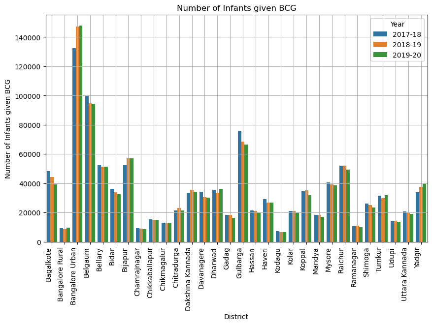

```python
fig, ax=plt.subplots(figsize=(10,6))
sns.barplot(data=names, x="District", y="Number of Infants given BCG", hue = 'Year',ax=ax)
ax.set_xticklabels(ax.get_xticklabels(),rotation=90,horizontalalignment='right')
ax.grid(True)
plt.title("Number of Infants given BCG")
plt.show()
```

### Inference:

-The graph gives about the distribution of BCG Vaccine given to infants for the prevention of tuberculosis.

### BCG Vaccine

#### BCG, or Bacille Calmette-Guerin, is a vaccine for tuberculosis (TB) disease to prevent childhood tuberculous meningitis(Brain Fever) and miliary disease(tubercle bacilli to the lungs).